# Clima do Paraná: Curitiba

NASA POWER, dados horários agregados por dia

# 1. Estatística descritiva

| variavel | media | mediana | moda | minimo | maximo | amplitude | variancia | desvio_pad | cv_pct | q1 | q3 | iqr |
| --- | --- | --- | --- | --- | --- | --- | --- | --- | --- | --- | --- | --- |
| Temperatura média (°C) | 18,31 | 18,66 | 22,3 | 4,23 | 27,67 | 23,44 | 16,55 | 4,07 | 22,21 | 15,55 | 21,62 | 6,08 |
| Temperatura máxima (°C) | 24,53 | 24,98 | 23,6 | 8,22 | 35,72 | 27,50 | 22,65 | 4,76 | 19,40 | 21,64 | 28,10 | 6,46 |
| Temperatura mínima (°C) | 13,64 | 13,87 | 12,2 | -2,01 | 22,18 | 24,19 | 15,76 | 3,97 | 29,11 | 10,96 | 16,77 | 5,81 |
| Ponto de orvalho (°C) | 14,13 | 14,45 | 14,1 | -4,34 | 21,82 | 26,16 | 15,05 | 3,88 | 27,45 | 11,64 | 17,16 | 5,52 |
| Chuva (mm/dia) | 3,97 | 1,17 | 0,0 | 0,00 | 58,16 | 58,16 | 45,36 | 6,74 | 169,81 | 0,12 | 4,99 | 4,87 |
| Umidade (%) | 79,85 | 80,34 | 81,5 | 47,00 | 98,27 | 51,27 | 69,78 | 8,35 | 10,46 | 74,38 | 85,92 | 11,54 |
| Radiação (MJ/m²/dia) | 15,81 | 15,63 | 15,8 | 1,02 | 32,67 | 31,65 | 43,64 | 6,61 | 41,79 | 11,32 | 20,33 | 9,01 |
| Vento a 2 m (m/s) | 0,95 | 0,90 | 0,7 | 0,34 | 2,97 | 2,63 | 0,09 | 0,29 | 30,82 | 0,73 | 1,12 | 0,40 |
| DPV (kPa) | 0,56 | 0,52 | 0,4 | 0,02 | 1,87 | 1,85 | 0,10 | 0,31 | 55,33 | 0,34 | 0,74 | 0,40 |

# 2. Gráficos

## 2.1 Distribuição da temperatura média diária

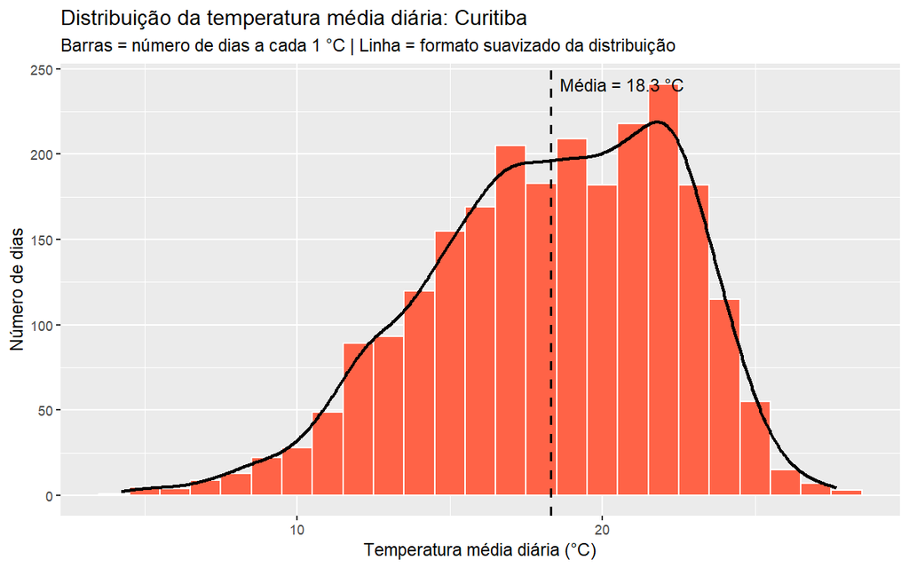

## 2.2 Dias por intensidade de chuva

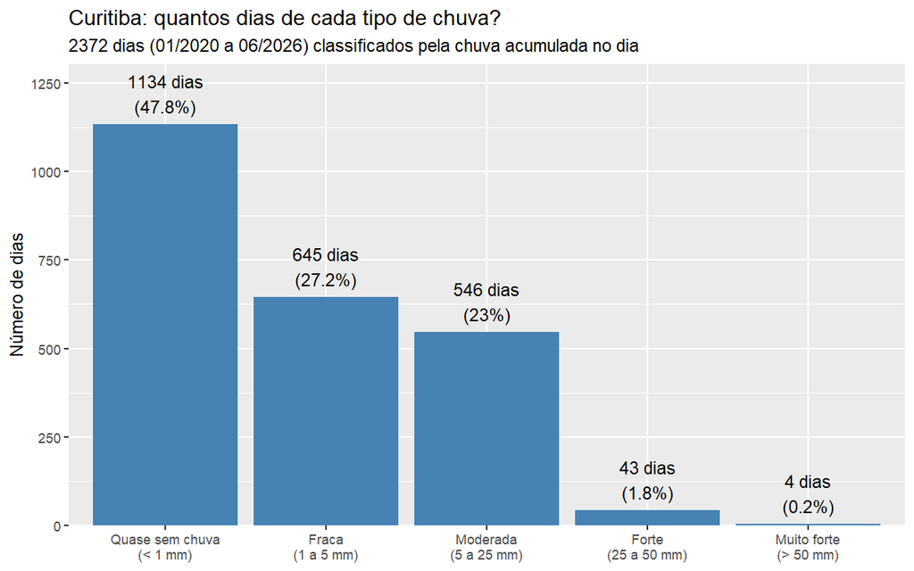

## 2.3 Temperatura média por mês

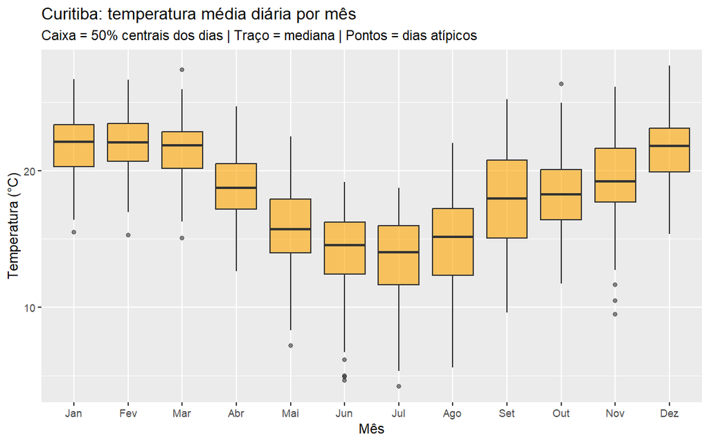

## 2.4 Temperatura ao longo do tempo

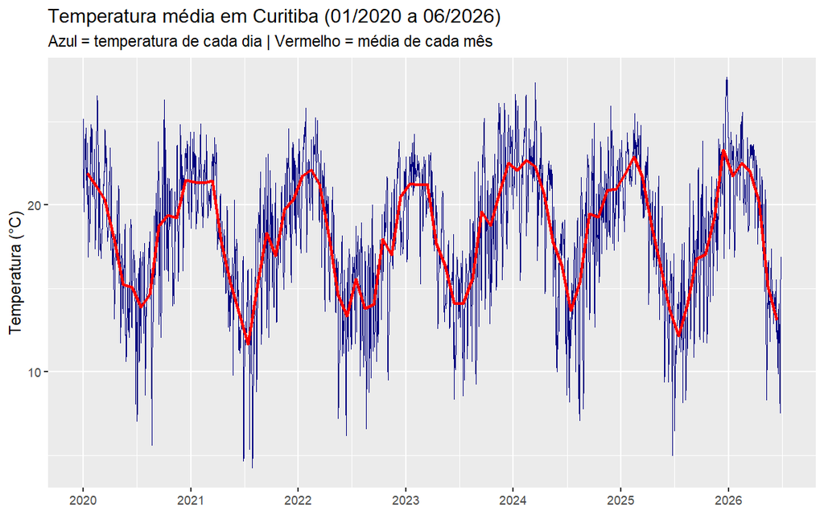

## 2.5 Radiação solar × temperatura

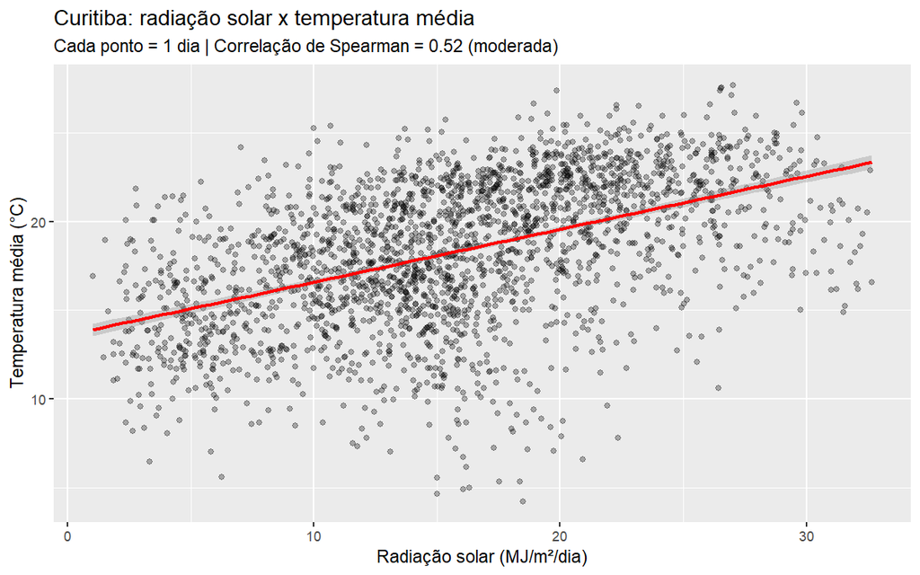

## 2.6 Temperaturas máxima, média e mínima por mês

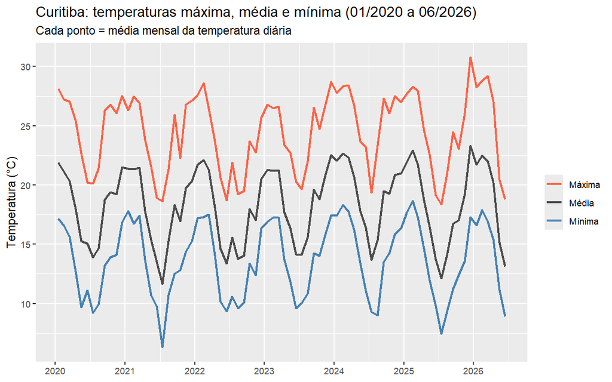

## 2.7 Velocidade do vento por mês

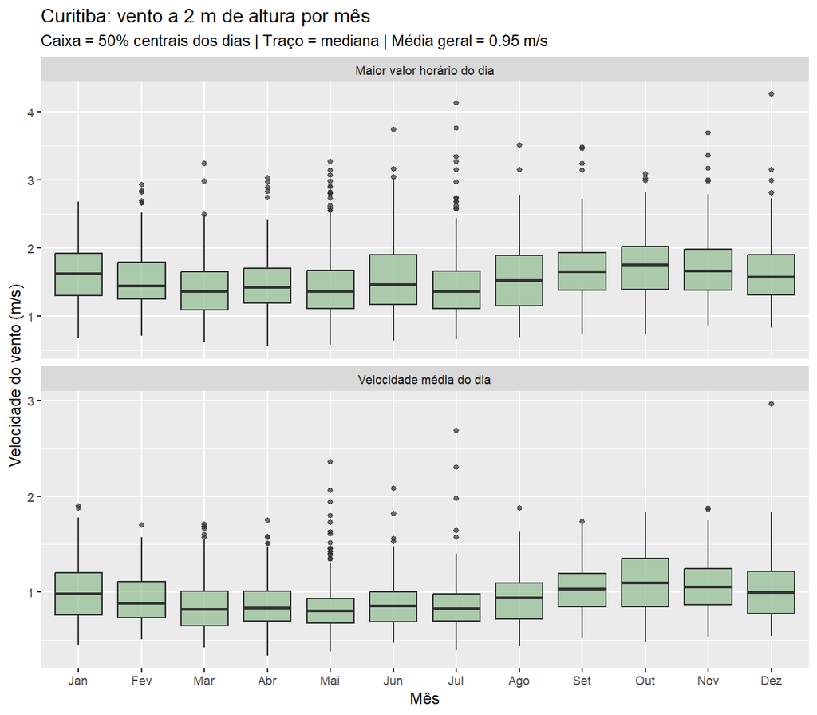

# 3. Teste de normalidade (Shapiro-Wilk)

| Variável | W | p-valor | Decisão |
| --- | --- | --- | --- |
| Temperatura média (°C) | 0.981 | < 0,001 | Não normal (rejeita H0) |
| Temperatura máxima (°C) | 0.982 | < 0,001 | Não normal (rejeita H0) |
| Temperatura mínima (°C) | 0.978 | < 0,001 | Não normal (rejeita H0) |
| Ponto de orvalho (°C) | 0.966 | < 0,001 | Não normal (rejeita H0) |
| Chuva (mm/dia) | 0.618 | < 0,001 | Não normal (rejeita H0) |
| Umidade (%) | 0.989 | < 0,001 | Não normal (rejeita H0) |
| Radiação (MJ/m²/dia) | 0.992 | < 0,001 | Não normal (rejeita H0) |
| Vento a 2 m (m/s) | 0.957 | < 0,001 | Não normal (rejeita H0) |
| DPV (kPa) | 0.960 | < 0,001 | Não normal (rejeita H0) |

## Q-Q plots

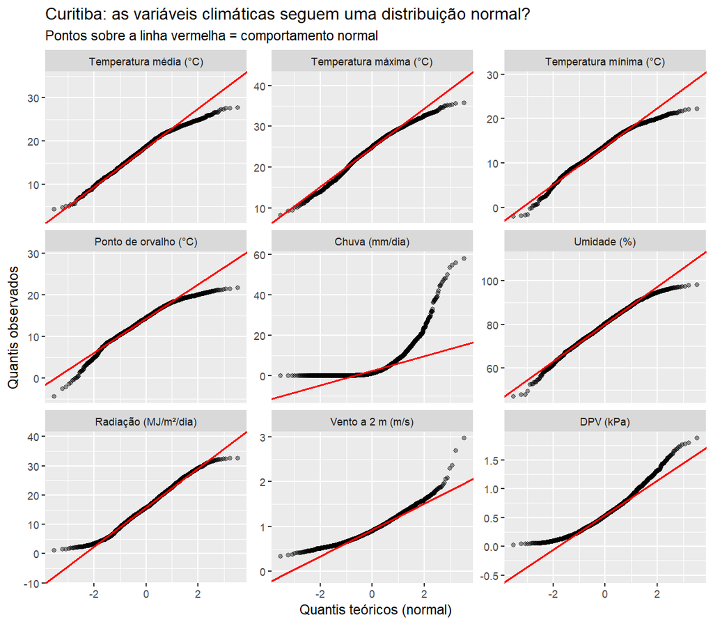

# 4. Teste de correlação (Spearman)

H0: não há correlação (rho = 0). H1: há correlação (rho ≠ 0). Escala de |rho|: 0,00-0,19 muito fraca; 0,20-0,39 fraca; 0,40-0,69 moderada; 0,70-0,89 forte; 0,90-1,00 muito forte.

Dos 36 pares, **32 são significativos** (p < 0,05).

| Par | rho | p-valor | Força | Sentido | Decisão |
| --- | --- | --- | --- | --- | --- |
| Temp. mín. × P. orvalho | 0.95 | < 0,001 | Muito forte | Positiva | Correlação significativa |
| Temp. média × Temp. máx. | 0.93 | < 0,001 | Muito forte | Positiva | Correlação significativa |
| Temp. média × Temp. mín. | 0.92 | < 0,001 | Muito forte | Positiva | Correlação significativa |
| Umidade × DPV | -0.89 | < 0,001 | Forte | Negativa | Correlação significativa |
| Temp. média × P. orvalho | 0.86 | < 0,001 | Forte | Positiva | Correlação significativa |
| Temp. máx. × DPV | 0.85 | < 0,001 | Forte | Positiva | Correlação significativa |
| Temp. máx. × Temp. mín. | 0.75 | < 0,001 | Forte | Positiva | Correlação significativa |
| Radiação × DPV | 0.75 | < 0,001 | Forte | Positiva | Correlação significativa |
| Temp. média × DPV | 0.67 | < 0,001 | Moderada | Positiva | Correlação significativa |
| Umidade × Radiação | -0.67 | < 0,001 | Moderada | Negativa | Correlação significativa |
| Temp. máx. × P. orvalho | 0.66 | < 0,001 | Moderada | Positiva | Correlação significativa |
| Temp. máx. × Radiação | 0.64 | < 0,001 | Moderada | Positiva | Correlação significativa |
| Chuva × Umidade | 0.62 | < 0,001 | Moderada | Positiva | Correlação significativa |
| Temp. máx. × Umidade | -0.55 | < 0,001 | Moderada | Negativa | Correlação significativa |
| Temp. média × Radiação | 0.52 | < 0,001 | Moderada | Positiva | Correlação significativa |
| P. orvalho × Chuva | 0.52 | < 0,001 | Moderada | Positiva | Correlação significativa |
| Temp. mín. × Chuva | 0.40 | < 0,001 | Moderada | Positiva | Correlação significativa |
| Temp. mín. × DPV | 0.40 | < 0,001 | Moderada | Positiva | Correlação significativa |
| Chuva × DPV | -0.40 | < 0,001 | Moderada | Negativa | Correlação significativa |
| Chuva × Radiação | -0.35 | < 0,001 | Fraca | Negativa | Correlação significativa |
| Temp. média × Umidade | -0.32 | < 0,001 | Fraca | Negativa | Correlação significativa |
| Temp. mín. × Radiação | 0.32 | < 0,001 | Fraca | Positiva | Correlação significativa |
| P. orvalho × DPV | 0.23 | < 0,001 | Fraca | Positiva | Correlação significativa |
| P. orvalho × Radiação | 0.20 | < 0,001 | Fraca | Positiva | Correlação significativa |
| Temp. média × Chuva | 0.19 | < 0,001 | Muito fraca | Positiva | Correlação significativa |
| Chuva × Vento | 0.19 | < 0,001 | Muito fraca | Positiva | Correlação significativa |
| P. orvalho × Umidade | 0.17 | < 0,001 | Muito fraca | Positiva | Correlação significativa |
| Vento × DPV | -0.11 | < 0,001 | Muito fraca | Negativa | Correlação significativa |
| Temp. máx. × Vento | -0.10 | < 0,001 | Muito fraca | Negativa | Correlação significativa |
| Radiação × Vento | -0.07 | 0,001 | Muito fraca | Negativa | Correlação significativa |
| Umidade × Vento | 0.06 | 0,002 | Muito fraca | Positiva | Correlação significativa |
| Temp. média × Vento | -0.05 | 0,014 | Muito fraca | Negativa | Correlação significativa |
| Temp. máx. × Chuva | -0.04 | 0,055 | Muito fraca | Negativa | Sem evidência de correlação |
| Temp. mín. × Umidade | -0.03 | 0,214 | Muito fraca | Negativa | Sem evidência de correlação |
| P. orvalho × Vento | -0.01 | 0,471 | Muito fraca | Negativa | Sem evidência de correlação |
| Temp. mín. × Vento | 0.00 | 0,869 | Muito fraca | Negativa | Sem evidência de correlação |

## Mapa de calor

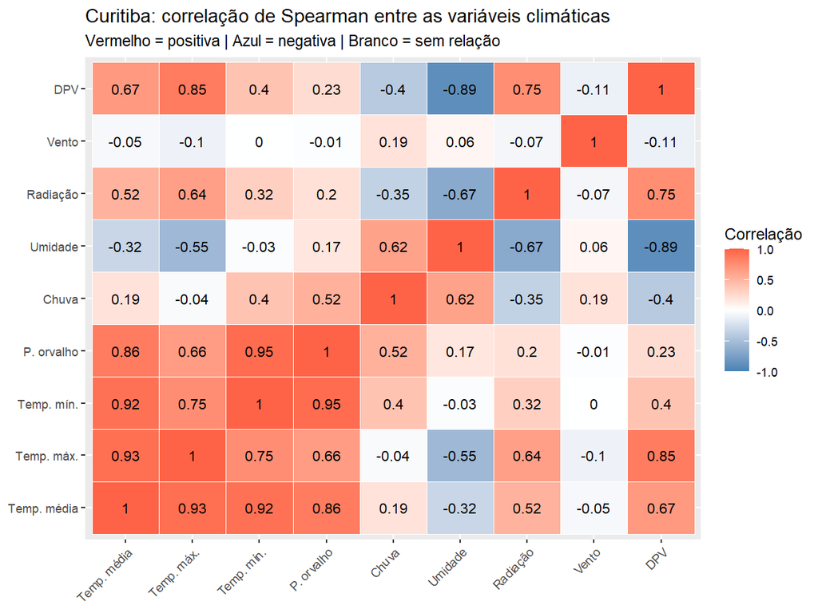

## Pearson (apenas para comparação: radiação × temperatura)

r = 0.48 (IC 95%: 0.45 a 0.51), p-valor < 0,001.

# Observações

- O NASA POWER é derivado de satélites e modelos (grade de ~50 km), não de estações; a chuva é a variável menos confiável.
- Os dados são **horários** (hora solar local) e foram agregados por dia: média para temperatura, umidade, vento, ponto de orvalho e DPV; soma dos valores horários para chuva (mm) e radiação (MJ/m²); máximo e mínimo dos valores horários para `temp_max`, `temp_min` e `vento_max`. Como cada valor horário já é uma média de uma hora, os extremos diários são um pouco mais suaves que os de uma estação.
- O DPV e o ponto de orvalho são calculados **hora a hora** (fórmula de Magnus) e só depois viram média diária, o que evita o viés de calcular a partir de médias diárias. Ainda assim, suas correlações com temperatura e umidade são em parte matemáticas.
- O período vai de 2020 até a data mais recente disponível (a NASA tem alguns dias de atraso). O último mês costuma estar incompleto, e a sazonalidade deixa os p-valores otimistas. Correlação não implica causa.